MRC Centre for Global Infectious Disease Analysis, Imperial College London

# Equatorial Guinea COVID-19 report

## Situation Report for COVID-19: Equatorial Guinea, 2020-05-30

#### **[Download the report for Equatorial Guinea, 2020-05-30 here](https://github.com/mrc-ide/global-lmic-reports/raw/master/GNQ/index.pdf).**

This report uses data from the European Centre for Disease Control. These data are updated daily and whilst there may be a short delay, they are generally consistent with Ministry reports. These data are then used to back-calculate an ‘inferred number of COVID-19 infections’ using mathematical modelling techniques (see [Report 12](https://www.imperial.ac.uk/mrc-global-infectious-disease-analysis/covid-19/report-12-global-impact-covid-19/) for further details) to estimate the number of people that have been infected and to make short-term projections for future healthcare needs.

### Epidemiological Situation

| **Total Reported Cases** | **New Reported Cases** | **Total Reported Deaths** | **New Reported Deaths** |
| --- | --- | --- | --- |
| 1,043 | 0 | 12 | 0 |

The figure below shows the cumulative reported deaths as a function of the time since the 10th death was reported. Dashed lines show the expected trajectory for different doubling times of the epidemic. For example, with a doubling time of 3 days, if there are currently a total of 20 deaths reported, we would expect there to be 40 deaths in total reported in 3 days-time, 80 deaths in 6 days-time, 160 deaths in 9 days-time etc. For most epidemics, in the absence of interventions, we expect a doubling time of 3-4 days for this disease.

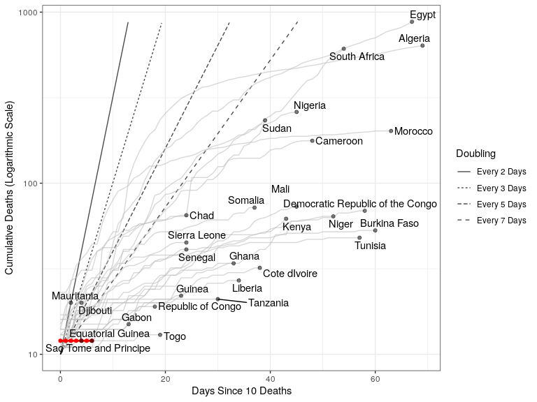

**Figure 1: Cumulative Deaths since 10 deaths.** Country not shown if fewer than 10 deaths.

### COVID-19 Transmission Modelling

To explore this, we fit our age-structured SEIR model (see [Methods](https://mrc-ide.github.io/global-lmic-reports/parameters.html)) to the time series of deaths in a country, in order to estimate the start date of the epidemic and the baseline R0. We assume that 100% of COVID-19 related deaths have been reported. We have also included the impact of interventions that have been put in place using data from the [Oxford Coronavirus Government Response Tracker](https://www.bsg.ox.ac.uk/research/research-projects/coronavirus-government-response-tracker). We currently make assumptions about the efficacy of these interventions and so the projections should be interpreted as scenarios rather than predictions. Using our [mathematical model](https://github.com/mrc-ide/squire) that formalises this approach, we estimate that there has been a total of 19,187 (95% CI: 17,313-21,062) infections over the past 4 weeks.

The figure below shows the estimated number of people infected over the past 4 weeks. The bar charts show, for comparison, the number of reported cases. The right-hand plot shows these data on a different scale as the estimated infections are likely to be much larger than the reported cases. **Importantly, the estimated infections includes both asymptomatic and mild cases that would not necessarily be identified through surveillance.** Consequently, the estimated infections are likely to be significantly higher than the reported cases (see our [FAQ](https://mrc-ide.github.io/global-lmic-reports/FAQ.html#why-are-the-estimated-infections-so-much-higher-than-the-reported-cases) for further explanation of these differences and why the reported cases and estimated infections are unlikely to match).

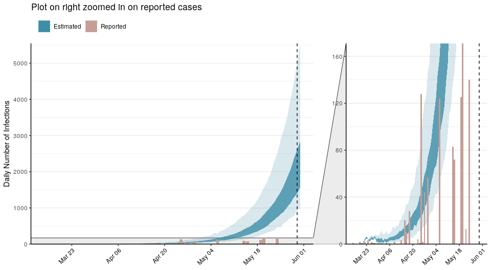

**Figure 2: Daily number of infections estimated by fitting to the current total of deaths.** Reported cases are shown in red. Model estimated infections are shown in blue (dark blue 50% interquartile range, light blue 95% quantile). The dashed line shows the current day.

The expected trajectory for cumulative deaths is shown in the figure below. This assumes a severity pattern by age that is consistent with that observed in China, Europe and the U.S to date. **N.B. Equatorial Guinea is forecast to be close to or supassing our best estimates for healthcare capacity in the next 14 days.** Estimates of deaths in the next 14 days may be inaccurate due to our working assumptions for mortality in individuals who do not receive appropriate treatment. [See our parameter sources for more information](https://mrc-ide.github.io/global-lmic-reports/parameters.html)

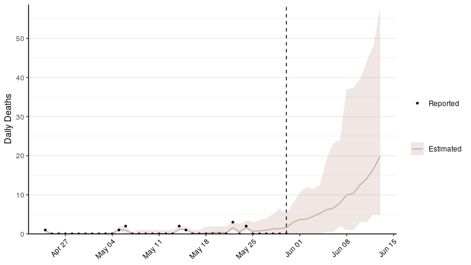

**Figure 3: Estimated daily deaths.** Projected deaths assuming the current level of interventions are maintained are shown in red (mean and 95% quantile). Reported deaths are plotted in black

### Short-term Epidemic Scenarios

We make the following short-term projections of healthcare demand and new infections under the following three scenarios:

- **Scenario 1.** The epidemic continues to grow at the current rate.
- **Scenario 2.** Countries will further scale up interventions (either increasing current strategies or implementing new interventions) leading to a further 50% reduction in transmission.
- **Scenario 3.** Countries will relax current interventions by 50%

Consequently, these predictions have one major caveat:

- The projections assume that 100% of COVID-19 related deaths have been reported.

We estimate that over the next 2 weeks demand for hospital beds will change from 107 (95% CI: 96-117) patients requiring treatment with high-pressure oxygen at the current date to 500 (95% CI: 456-544) hospital beds being required on 2020-06-13 if no further interventions are introduced (Scenario 1). Similarly, we estimate that over the next 2 weeks demand for critical care (ICU) beds will change from 26 (95% CI: 24-29) patients requiring treatment with mechanical ventilation at the current date to 103 (95% CI: 97-109) by 2020-06-13. These projections assume that approximately 5% of all infections will require treatment with high-pressure oxygen and that approximately 30% of hospitalised cases will require treatment with mechanical ventilation (based on analysis of ongoing epidemics in Europe). **N.B. The difference between scenrarios will not be significantly different in the first 7 days**. This is due to the approximate 10 day delay between infection and hospital admission. Consequently, the effectiveness of a change in policy is likely to be better captured by hospital admission data approximately 2 weeks after a policy change is implemented.

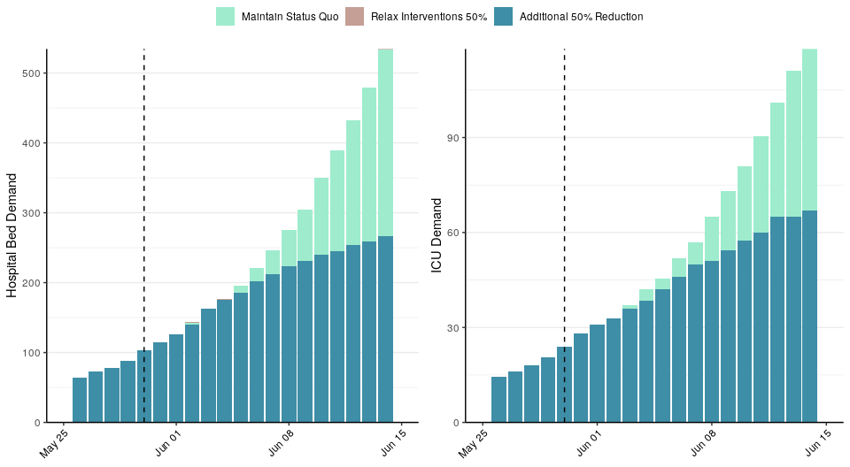

**Figure 4: Healthcare demands in the next 2 weeks.** Individuals needing an ICU bed are assumed to need mechanical ventilation. Projected demand for Scenario 1 (the epidemic continues to grow at the current rate) are shown in green (Maintain status quo). Projections for Scenario 2 (a further 50% reduction in transmission) are shown in blue. Projections for Scenario 3 (relaxing interventions by 50%) are shown in red. The dashed line shows the current day.

The impact of each scenario has a more immediate effect on the daily number of infections. The figure below shows the impact of each scenario on the estimated daily incidence of new infections. If interventions are scaled up (Scenario 2), the daily number of infections will change from 2,183 (95% CI: 1,975-2,390) at the current date to 2,336 (95% CI: 2,131-2,541) by 2020-06-13. If current interventions were relaxed by 50%, we estimate the daily number of infections will change from 2,183 (95% CI: 1,975-2,390) at the current date to 9,593 (95% CI: 8,856-10,330) by 2020-06-13.

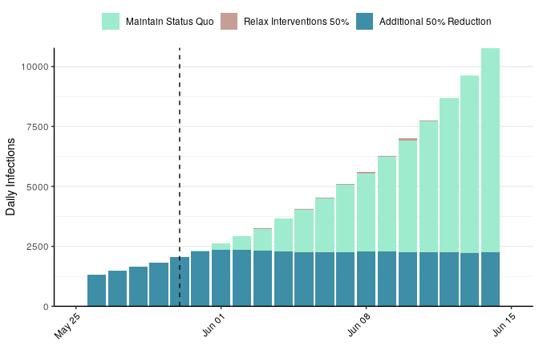

**Figure 5: Daily number of infections estimated by fitting to the current total of deaths.** Projected infections for Scenario 1 (the epidemic continues to grow at the current rate) are shown in green (Maintain status quo). Projections for Scenario 2 (a further 50% reduction in transmission) are shown in blue. Projections for Scenario 3 (relaxing interventions by 50%) are shown in red. The dashed line shows the current day.

Copyright © 2020 Imperial College London. MRC Centre for Global Infectious Disease Analysis. All rights reserved.

Funded by the Wellcome Trust and The Department for International Development